## Modifying Notebook display

```python
from IPython.display import display, HTML

display(HTML(data="""
<style>
    .container#notebook-container    { width: 95%;}
    div#menubar-container     { width: 95%; }
    div#maintoolbar-container { width: 95%; }
</style>
<script>
    document.getElementById("notebook-container").style.margin = "auto";
</script>
"""))
```

## For running the notebook as Google Colab Instance

# mounting the google drive for accessing other necessary files

from google.colab import drive drive.mount('/content/gdrive')

# Checking the available files in the "Colab Notebooks" folder of the google drive

!ls /content/gdrive/My\ Drive/Colab\ Notebooks

import sys

# changing the current working directory to "Colab Notebooks" folder in the google drive

sys.path.append('/content/gdrive/My Drive/Colab Notebooks')

## For running the notebook as Kaggle Kernel

change directory to the dataset where our custom scripts are uploaded

> `os.chdir("/kaggle/input/handwritten-digit-recognition")`

*handwritten-digit-recognition* is simply a folder name. It can vary based on the dataset you create in kaggle while uploading the python scripts.

load custom module or files or dataset

> `from dataset import load_dataset, train_dev_split, prep_dataset`  
> `from dataset import visualize_data_distribution, visualize_dataset`

reset our working directory

> `os.chdir("/kaggle/working/")`

**NOTE:** The *input directory* is Read-Only. So, we must switch back to the *working directory* for performing any other operation that requires write access. Make sure this note book runs as a part of the dataset you create as said above because all the custom modules are uploaded there.

## Importing Dependencies

```python
import time    #for calculating time
import os
#core packages
import numpy as np
import matplotlib.pyplot as plt

# os.chdir("/kaggle/input/handwritten-digit-recognition")

#custom module
from dataset import load_dataset, train_dev_split, prep_dataset
from dataset import visualize_data_distribution, visualize_dataset

from ModelUtils import relu, relu_grad, softmax
from ModelUtils import rand_mini_batches, convert_time
from ModelUtils import confusion_matrix, plot_confusion_matrix, model_metrics, metric_summary
from ModelUtils import visualize_training_results, visualize_prediction, visualize_mislabelled_images
from ModelUtils import save_model, load_model

from dataAugmentation import data_generator

from ffnn import *


# np.random.seed(1)
%matplotlib inline
```

## Dataset Preparation

### Loading Dataset

```python
dataset_size_in_per = 100

train_x_orig, train_y_orig, test_x_orig, test_y_orig = load_dataset(dataset = "mnist", size_in_per = dataset_size_in_per)

print("Sample Size : %d%%\n"%(dataset_size_in_per))
print("Data\t\t\t","Datatype\t\t","Dataset Size")
print("=================================================================")
print("Training Set Images:\t" + str(type(train_x_orig))+"\t",str(train_x_orig.shape))
print("Training Set Labels:\t" + str(type(train_y_orig))+"\t",str(train_y_orig.shape))
print("Test Set Images:\t" + str(type(test_x_orig))+"\t",str(test_x_orig.shape))
print("Test Set Labels:\t" + str(type(test_y_orig))+"\t",str(test_y_orig.shape))
print("=================================================================")
```

```
Sample Size : 100%

Data			 Datatype		 Dataset Size
=================================================================
Training Set Images:	<class 'numpy.ndarray'>	 (60000, 28, 28)
Training Set Labels:	<class 'numpy.ndarray'>	 (60000, 1)
Test Set Images:	<class 'numpy.ndarray'>	 (10000, 28, 28)
Test Set Labels:	<class 'numpy.ndarray'>	 (10000, 1)
=================================================================
```

### Train-Dev set Split

```python
train_x_split, train_y_split, dev_x_split, dev_y_split = train_dev_split(train_x_orig, train_y_orig)

print("Data\t\t\t\t","Datatype\t\t","Shape")
print("========================================================================")
print("Training Set Images:\t\t" + str(type(train_x_split))+"\t",str(train_x_split.shape))
print("Training Set Labels:\t\t" + str(type(train_y_split))+"\t",str(train_y_split.shape))
print("Development Set Images:\t\t" + str(type(dev_x_split))+"\t",str(dev_x_split.shape))
print("Development Set Labels:\t\t" + str(type(dev_y_split))+"\t",str(dev_y_split.shape))
print("========================================================================")
```

```
Data				 Datatype		 Shape
========================================================================
Training Set Images:		<class 'numpy.ndarray'>	 (50000, 28, 28)
Training Set Labels:		<class 'numpy.ndarray'>	 (50000, 1)
Development Set Images:		<class 'numpy.ndarray'>	 (10000, 28, 28)
Development Set Labels:		<class 'numpy.ndarray'>	 (10000, 1)
========================================================================
```

### Visualizing Data Distribution

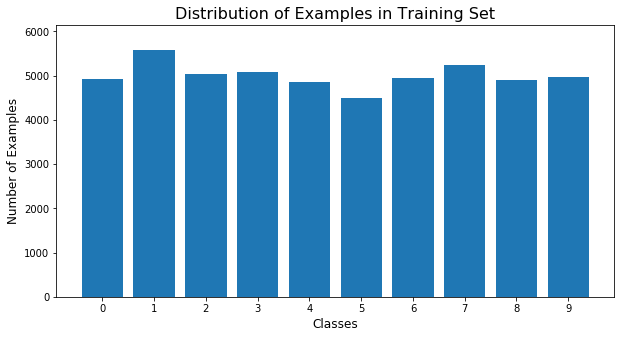

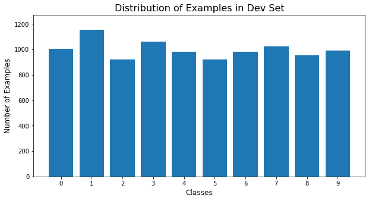

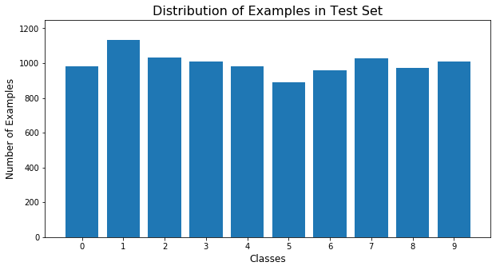

```python
visualize_data_distribution(train_y_split, dataset_type = "training")
visualize_data_distribution(dev_y_split,  dataset_type = "dev")
visualize_data_distribution(test_y_orig,  dataset_type = "test")
```

### Visualizing Dataset

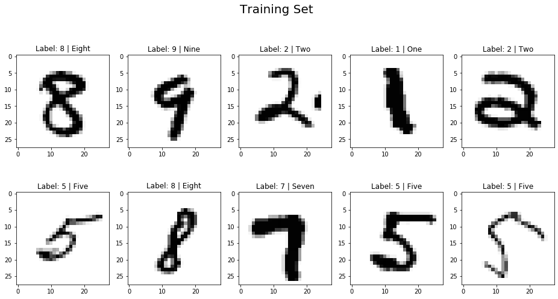

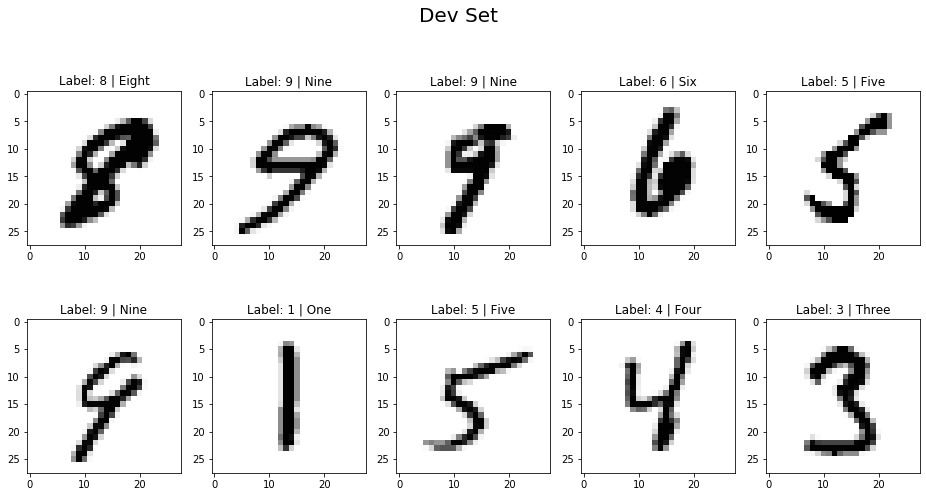

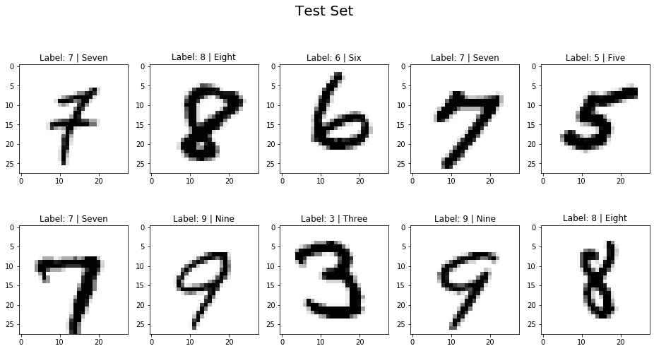

```python
visualize_dataset(train_x_split, train_y_split, dataset = "mnist", dataset_type = "training")
visualize_dataset(dev_x_split, dev_y_split, dataset = "mnist", dataset_type = "dev")
visualize_dataset(test_x_orig, test_y_orig, dataset = "mnist", dataset_type="test")
```

### Preparing Dataset

The preprocess training set will only be used later during prediction. The splitted training set will be directly fed to the model and it is preprocessed in the fly during the augmentation process.

```python
train_x_norm, train_y_encoded = prep_dataset(train_x_split, train_y_split, num_class = 10)
dev_x_norm, dev_y_encoded= prep_dataset(dev_x_split, dev_y_split, num_class = 10)
test_x_norm, test_y_encoded = prep_dataset(test_x_orig, test_y_orig, num_class = 10)

print("Data\t\t\t","Before Processing\t","After Processing")
print("=================================================================")
print("Training Set Images:\t" + str(train_x_split.shape)+"\t\t"+ str(train_x_norm.shape))
print("Training Set Labels:\t" + str(train_y_split.shape)+"\t\t"+ str(train_y_encoded.shape))
print("Dev Set Images:\t\t" + str(dev_x_split.shape)+"\t\t"+ str(dev_x_norm.shape))
print("Dev Set Labels:\t\t" + str(dev_y_split.shape)+"\t\t"+ str(dev_y_encoded.shape))
print("Test Set Images:\t" + str(test_x_orig.shape)+"\t\t"+ str(test_x_norm.shape))
print("Test Set Labels:\t" + str(test_y_orig.shape)+"\t\t"+ str(test_y_encoded.shape))
print("=================================================================")
```

```
Data			 Before Processing	 After Processing
=================================================================
Training Set Images:	(50000, 28, 28)		(784, 50000)
Training Set Labels:	(50000, 1)		(10, 50000)
Dev Set Images:		(10000, 28, 28)		(784, 10000)
Dev Set Labels:		(10000, 1)		(10, 10000)
Test Set Images:	(10000, 28, 28)		(784, 10000)
Test Set Labels:	(10000, 1)		(10, 10000)
=================================================================
```

### Train Model

```python
# Final Model Training

def train(X_train, Y_train, X_dev, Y_dev, layers_dim, hyperParams, initialization = "random", optimizer = 'bgd',regularizer = None, verbose = 3, patience = 10):
    # loading the hyper parameters
    learning_rate = hyperParams['learning_rate']
    num_epoch = hyperParams['num_epoch']
    b1 = hyperParams['beta1']
    b2 = hyperParams['beta2']
    ep = hyperParams['epsilon']
    lambd = hyperParams['lambda']
    keep_probs = hyperParams['keep_probs']

    #validating Early Stopping
    assert(patience == 0 or patience >=5), "Evaluate the accuracy of at least 5 epoch before early stopping"
    #setting up path for saving intermediate best model in a temp folder
    path = "temp/"
    if not os.path.exists(path):
        os.makedirs(path)
    filename = "best_param_intermediate"

    #initializing the variables
    seed = 1
    m = Y_train.shape[1]
    train_accs = []  # keep track of training accuracy
    val_accs = []     # keep track of Validation accuracy
    train_losses = []  # keep track of training loss
    val_losses = []     # keep track of Validation loss

    early_stop_count = 0 #for early stopping
    max_val_acc = 0 # for keeping track of maximum validation accuracy
    best_param = {}

    #selecting the minibatch size for each optimizer
    if optimizer == 'sgd':
        mini_batch_size = 1
    elif optimizer == 'bgd':
        mini_batch_size = m
    elif optimizer == 'mgd' or optimizer == 'adam':
        mini_batch_size = hyperParams['mini_batch_size']
    else:
        raise ValueError("Optimizer value out of scope")

    #initializing the model parameters
    parameters = init_parameters(layers_dim, initialization)

    #initializing adam parameters, used only when optimizer = 'adam'
    t = 0
    v,s = initialize_adam(parameters)

    train_toc = time.time() # for calculating entire training time
    print("Training The Model...")

    #Gradient Descent begins
    for i in range(1, num_epoch+1):
        seed += 1
        time_trained = 0
        batch_times = []
        accs = []
        losses = []

        if verbose > 0:
            print("\nEpoch %d/%d"%(i,num_epoch))

        #augmenting dataset online
        augmented_images, augmented_labels = data_generator(X_train, Y_train, batch_size = 2048, aug_count = 1, pre_process_data = True)

        minibatches = rand_mini_batches(augmented_images, augmented_labels, mini_batch_size, seed)
        total_minibatches = len(minibatches)

        #clearing the memory of unused data because once the minibatches are created they have no use
        augmented_images = augmented_labels = 0

        for ind, minibatch in enumerate(minibatches):
            batch_toc = time.time() # for calculating time of an epoch cycle

            #retriving minibatch of X and Y from training set
            (minibatch_X, minibatch_Y) = minibatch

            #forward Propagation
            AL, caches, dropout_masks = forward_prop(minibatch_X, parameters, keep_probs = keep_probs, regularizer = regularizer)

            #Computing cross entropy cost
            cross_entropy_cost = softmax_cross_entropy_cost(AL, minibatch_Y, caches, lambd = lambd, regularizer = regularizer, from_logits = True) #accumulating the batch costs

            #Backward Propagation
            grads = backward_prop(AL, minibatch_Y, caches, dropout_masks = dropout_masks, keep_probs = keep_probs, lambd = lambd, regularizer = regularizer)

            #Updating parameters
            t += 1
            parameters, v, s = update_parameters(parameters, grads, learning_rate, optimizer = optimizer, beta1 = b1, beta2 = b2,  epsilon = ep, v = v, s = s, t = t)

            # Calculating training time for each batch
            batch_tic = time.time()
            batch_times.append(batch_tic - batch_toc)
            time_trained = np.sum(batch_times)

            #calculating training progress
            per = ((ind+1) / total_minibatches) * 100
            inc = int(per // 10) * 2

            #calculating accuracy and loss of the training batch
            acc,loss = evaluate(minibatch_X, minibatch_Y, parameters)
            accs.append(acc)
            losses.append(loss)

            #averaging all the accs and losses till now
            train_acc = np.mean(accs)
            train_loss = np.mean(losses)

            #Verbosity 0: Silent mode
            #Verbosity 1: Epoch mode
            #Verbosity 2: Progress bar mode
            #Verbosity 3 or greater: Metric mode

            if verbose == 2:
                print ("%d/%d [%s>%s %.0f%%] - %.2fs"%(ind+1, total_minibatches, '=' * inc,'.'*(20-inc), per, time_trained),end='\r')
            elif verbose > 2:
                print ("%d/%d [%s>%s %.0f%%] - %.2fs | loss: %.4f | acc: %.4f"%(ind+1, total_minibatches, '=' * inc,'.'*(20-inc), per, time_trained, train_loss, train_acc),end='\r')

        #----------------------------------------------batch ends-------------------------------------------
        #clearing the memory of unused data because once the minibatches are trained they have no use as new set of minibatches are created in each epoch
        minibatches = 0

        #accumulating the acc and loss of the last iteration of each epoch
        train_accs.append(np.mean(accs))
        train_losses.append(np.mean(losses))

        #evaluating the model using validation accuracy and loss
        val_acc, val_loss= evaluate(X_dev, Y_dev, parameters)
        val_accs.append(val_acc)
        val_losses.append(val_loss)


        time_per_batch = int(np.mean(batch_times)*1000)

        if verbose == 2:
            print ("%d/%d [%s 100%%] - %.2fs %dms/step"%(total_minibatches, total_minibatches, '=' * 20, time_trained, time_per_batch ),end='\r')
        elif verbose > 2:
            print ("%d/%d [%s 100%%] - %.2fs %dms/step | loss: %.4f | acc: %.4f | val_loss: %.4f | val_acc: %.4f"%(total_minibatches, total_minibatches, '=' * 20, time_trained, time_per_batch, train_loss, train_acc, val_loss, val_acc),end='\r')



        #getting the best val accuracy
        if val_acc >= max_val_acc:
            max_val_acc = val_acc
            best_param = parameters
            print("\nBetter validation accuracy found. So saving the corresponding parameters...")
            save_model(path+filename, best_param)

        # Early Stopping
        if patience >= 5:
            epoch_trained = i+1

            if val_acc < max_val_acc:
                early_stop_count += 1
            else:
                early_stop_count = 0

            if early_stop_count == patience:
                print("\n\nSince the Val Acc didn't increase for last %d epochs, Training is halted returning the best parameters obtained."%patience)
                break;
    #-------------------------------------------Gradient Descent ends-----------------------------------------------

    train_tic = time.time() # for calculating entire training time
    hrs, mins, secs , ms = convert_time((train_tic - train_toc)*1000)
    print("\n\nTotal Training Time = %dhr %dmins %dsecs %.2fms"%(hrs, mins, secs, ms))

    #loading the last saved best parameters
    best_param = load_model(path+filename)

    history = {"parameters":parameters,
               "best_params": best_param,
               "accuracy": train_accs,
               "loss":train_losses ,
               "val_accuracy":val_accs,
               "val_loss":val_losses
            }
    return history
```

#### Running Model

```python
layers_dim = init_layers(784, 10, hidden_layers = [1200])
hyperParams = init_hyperParams(alpha = 0.001485, num_epoch = 100, minibatch_size = 162, keep_probs = [0.9])
history = train(train_x_split, train_y_split, dev_x_norm, dev_y_encoded,layers_dim, hyperParams, initialization = "he", optimizer = 'adam',regularizer = "dropout", verbose = 3, patience = 20)
```

```
Training The Model...

Generating the Augmented Dataset...
Better validation accuracy found. So saving the corresponding parameters...

Generating the Augmented Dataset...
Better validation accuracy found. So saving the corresponding parameters...

Generating the Augmented Dataset...
Better validation accuracy found. So saving the corresponding parameters...

Generating the Augmented Dataset...
Better validation accuracy found. So saving the corresponding parameters...

Generating the Augmented Dataset...
Generating the Augmented Dataset...
Better validation accuracy found. So saving the corresponding parameters...

Generating the Augmented Dataset...
Better validation accuracy found. So saving the corresponding parameters...

Generating the Augmented Dataset...
Generating the Augmented Dataset...
Generating the Augmented Dataset...
Better validation accuracy found. So saving the corresponding parameters...

Generating the Augmented Dataset...
Generating the Augmented Dataset...
Generating the Augmented Dataset...
Generating the Augmented Dataset...
Better validation accuracy found. So saving the corresponding parameters...

Generating the Augmented Dataset...
Generating the Augmented Dataset...
Generating the Augmented Dataset...
Generating the Augmented Dataset...
Generating the Augmented Dataset...
Generating the Augmented Dataset...
Generating the Augmented Dataset...
Better validation accuracy found. So saving the corresponding parameters...
```

[output cut: 11 more lines]

```
Generating the Augmented Dataset...
Generating the Augmented Dataset...
Generating the Augmented Dataset...
Generating the Augmented Dataset...
Generating the Augmented Dataset...
Generating the Augmented Dataset...
Generating the Augmented Dataset...
Generating the Augmented Dataset...
Generating the Augmented Dataset...
Generating the Augmented Dataset...

Since the Val Acc didn't increase for last 20 epochs, Training is halted returning the best parameters obtained.


Total Training Time = 0hr 55mins 3secs 253.96ms
```

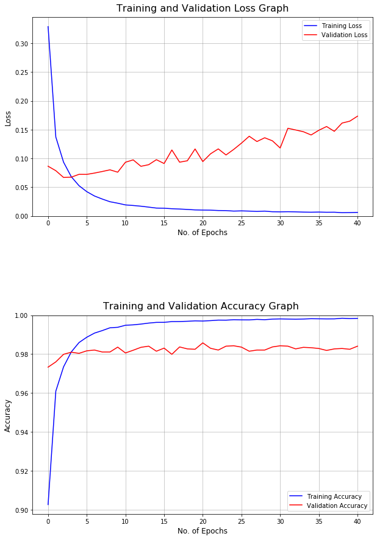

```python
# params = history["parameters"]
params = history["best_params"]
train_acc = history["accuracy"]
train_loss = history["loss"]
val_acc = history["val_accuracy"]
val_loss = history["val_loss"]
epochs = len(val_acc)


visualize_training_results(train_acc, val_acc, train_loss, val_loss)
```

```python
print("\n Epochs\t | Train Acc\t | Train Loss\t | Val Acc\t | Val Loss")
print("--------------------------------------------------------------------")
for i in range(epochs):
    print(" %d\t | %f\t | %f\t | %f\t | %f"%(i+1,train_acc[i] ,train_loss[i],val_acc[i] ,val_loss[i] ))
```

```
 Epochs	 | Train Acc	 | Train Loss	 | Val Acc	 | Val Loss
--------------------------------------------------------------------
 1	 | 0.902571	 | 0.328874	 | 0.973300	 | 0.086338
 2	 | 0.960951	 | 0.137088	 | 0.976000	 | 0.078610
 3	 | 0.973448	 | 0.093417	 | 0.979900	 | 0.066864
 4	 | 0.981127	 | 0.068126	 | 0.981000	 | 0.067345
 5	 | 0.985955	 | 0.052529	 | 0.980400	 | 0.072262
 6	 | 0.988684	 | 0.042225	 | 0.981700	 | 0.072184
 7	 | 0.990823	 | 0.034629	 | 0.982100	 | 0.074481
 8	 | 0.992109	 | 0.029374	 | 0.981100	 | 0.077180
 9	 | 0.993552	 | 0.024684	 | 0.981100	 | 0.080095
 10	 | 0.993807	 | 0.022144	 | 0.983600	 | 0.075992
 11	 | 0.994853	 | 0.019162	 | 0.980600	 | 0.093281
 12	 | 0.995068	 | 0.018144	 | 0.982000	 | 0.097399
 13	 | 0.995462	 | 0.016921	 | 0.983500	 | 0.086214
 14	 | 0.995971	 | 0.015320	 | 0.984100	 | 0.088986
 15	 | 0.996336	 | 0.013664	 | 0.981500	 | 0.097698
 16	 | 0.996361	 | 0.013401	 | 0.983100	 | 0.091044
 17	 | 0.996746	 | 0.012539	 | 0.979900	 | 0.114604
 18	 | 0.996777	 | 0.011988	 | 0.983700	 | 0.093384
 19	 | 0.996911	 | 0.011306	 | 0.982700	 | 0.095834
 20	 | 0.997111	 | 0.010468	 | 0.982500	 | 0.116368
 21	 | 0.997032	 | 0.010201	 | 0.985800	 | 0.094431
 22	 | 0.997231	 | 0.010059	 | 0.983000	 | 0.107906
 23	 | 0.997506	 | 0.009419	 | 0.982100	 | 0.116454
 24	 | 0.997477	 | 0.009260	 | 0.984100	 | 0.105911
 25	 | 0.997702	 | 0.008421	 | 0.984300	 | 0.115608
 26	 | 0.997631	 | 0.008790	 | 0.983600	 | 0.126503
 27	 | 0.997611	 | 0.008394	 | 0.981500	 | 0.138431
 28	 | 0.997876	 | 0.007870	 | 0.982100	 | 0.129252
 29	 | 0.997717	 | 0.008364	 | 0.982100	 | 0.135773
 30	 | 0.998016	 | 0.007281	 | 0.983700	 | 0.130488
 31	 | 0.998121	 | 0.007119	 | 0.984300	 | 0.118016
 32	 | 0.998042	 | 0.007340	 | 0.984100	 | 0.152281
 33	 | 0.997971	 | 0.007105	 | 0.982700	 | 0.149315
 34	 | 0.998056	 | 0.006681	 | 0.983500	 | 0.146275
 35	 | 0.998226	 | 0.006488	 | 0.983300	 | 0.140633
 36	 | 0.998176	 | 0.006738	 | 0.982900	 | 0.148819
 37	 | 0.998126	 | 0.006399	 | 0.981900	 | 0.155316
 38	 | 0.998146	 | 0.006484	 | 0.982700	 | 0.146984
 39	 | 0.998456	 | 0.005671	 | 0.982900	 | 0.161310
 40	 | 0.998307	 | 0.005844	 | 0.982500	 | 0.164640
 41	 | 0.998396	 | 0.006176	 | 0.984100	 | 0.173309
```

### Prediction

```python
prediction_train = predict(train_x_norm, params, second_guess = True)
prediction_dev = predict(dev_x_norm,params, second_guess = True)
prediction_test = predict(test_x_norm, params, second_guess = True)
```

### Confusion Matrix

```python
cm_train = confusion_matrix(train_y_split, prediction_train)
cm_dev = confusion_matrix(dev_y_split, prediction_dev)
cm_test = confusion_matrix(test_y_orig, prediction_test)
```

```python
#plotting the confusion matrix
plot_confusion_matrix(cm_train, dataset_type = "training")
```

[output not shown]

```python
plot_confusion_matrix(cm_dev, dataset_type = "dev")
```

[output not shown]

```python
plot_confusion_matrix(cm_test, dataset_type = "test")
```

[output not shown]

```python
metrics, macro_metrics, acc = model_metrics(cm_train)
metric_summary(metrics, macro_metrics, acc)
```

```
+===============+===============+===============+===============+
| Label 	| Precision 	| Recall 	| F1 Score 	|
+===============+===============+===============+===============+
| 0 		|  0.99959 	|  0.99939 	|  0.99949 	|
| 1 		|  0.99946 	|  0.99964 	|  0.99955 	|
| 2 		|  0.99861 	|  0.99921 	|  0.99891 	|
| 3 		|  0.99901 	|  0.99882 	|  0.99892 	|
| 4 		|  0.99815 	|  0.99959 	|  0.99887 	|
| 5 		|  0.99889 	|  0.99867 	|  0.99878 	|
| 6 		|  0.99878 	|  0.99959 	|  0.99919 	|
| 7 		|  0.99962 	|  0.99809 	|  0.99885 	|
| 8 		|  0.99796 	|  0.99898 	|  0.99847 	|
| 9 		|  0.99899 	|  0.99718 	|  0.99808 	|
+===============+===============+===============+===============+
| Macro Avg 	|  0.99891 	|  0.99892 	|  0.99891 	|
+===============+===============+===============+===============+

 Accuracy 		  0.99892
```

```python
metrics, macro_metrics, acc = model_metrics(cm_dev)
metric_summary(metrics, macro_metrics, acc)
```

```
+===============+===============+===============+===============+
| Label 	| Precision 	| Recall 	| F1 Score 	|
+===============+===============+===============+===============+
| 0 		|  0.99303 	|  0.99205 	|  0.99254 	|
| 1 		|  0.99140 	|  0.99654 	|  0.99397 	|
| 2 		|  0.98694 	|  0.98587 	|  0.98641 	|
| 3 		|  0.98949 	|  0.97736 	|  0.98339 	|
| 4 		|  0.97976 	|  0.98675 	|  0.98324 	|
| 5 		|  0.98259 	|  0.97939 	|  0.98099 	|
| 6 		|  0.98584 	|  0.99085 	|  0.98834 	|
| 7 		|  0.98445 	|  0.98829 	|  0.98637 	|
| 8 		|  0.98115 	|  0.98115 	|  0.98115 	|
| 9 		|  0.98174 	|  0.97778 	|  0.97976 	|
+===============+===============+===============+===============+
| Macro Avg 	|  0.98564 	|  0.98560 	|  0.98561 	|
+===============+===============+===============+===============+

 Accuracy 		  0.98580
```

```python
metrics, macro_metrics, acc = model_metrics(cm_test)
metric_summary(metrics, macro_metrics, acc)
```

```
+===============+===============+===============+===============+
| Label 	| Precision 	| Recall 	| F1 Score 	|
+===============+===============+===============+===============+
| 0 		|  0.99388 	|  0.99490 	|  0.99439 	|
| 1 		|  0.99210 	|  0.99559 	|  0.99384 	|
| 2 		|  0.97699 	|  0.98740 	|  0.98217 	|
| 3 		|  0.98134 	|  0.98911 	|  0.98521 	|
| 4 		|  0.97872 	|  0.98371 	|  0.98121 	|
| 5 		|  0.99545 	|  0.98206 	|  0.98871 	|
| 6 		|  0.98646 	|  0.98852 	|  0.98749 	|
| 7 		|  0.98328 	|  0.97276 	|  0.97800 	|
| 8 		|  0.98364 	|  0.98768 	|  0.98566 	|
| 9 		|  0.98796 	|  0.97621 	|  0.98205 	|
+===============+===============+===============+===============+
| Macro Avg 	|  0.98598 	|  0.98579 	|  0.98587 	|
+===============+===============+===============+===============+

 Accuracy 		  0.98590
```

#### Visualizating Prediction

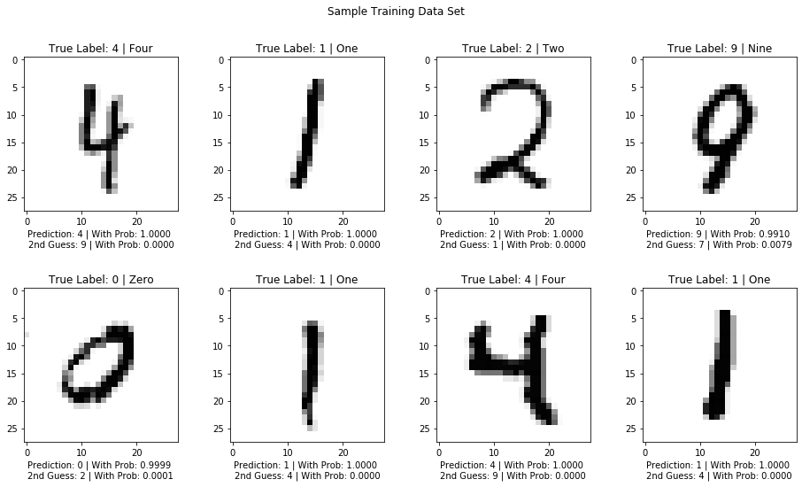

```python
visualize_prediction(train_x_split, train_y_split.T, prediction_train, dataset_type = "training")
```

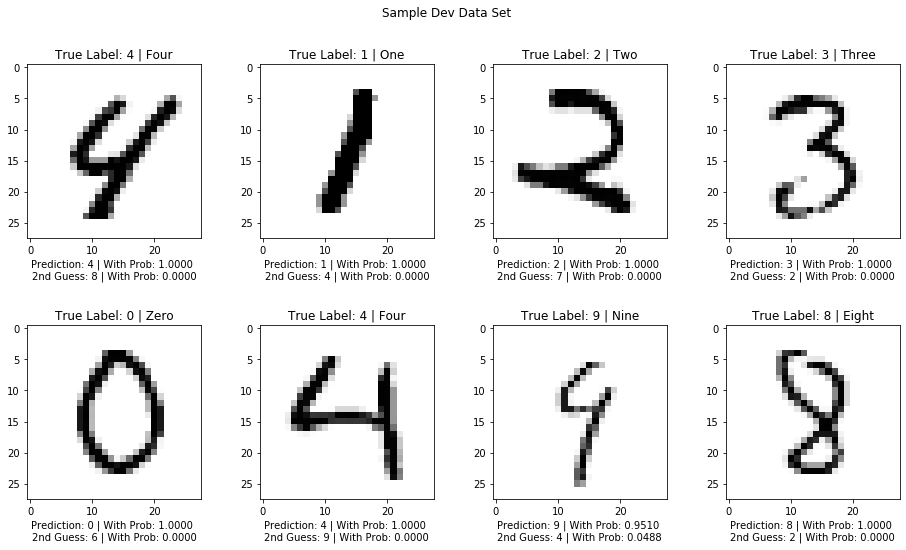

```python
visualize_prediction(dev_x_split, dev_y_split.T, prediction_dev, dataset_type = "dev")
```

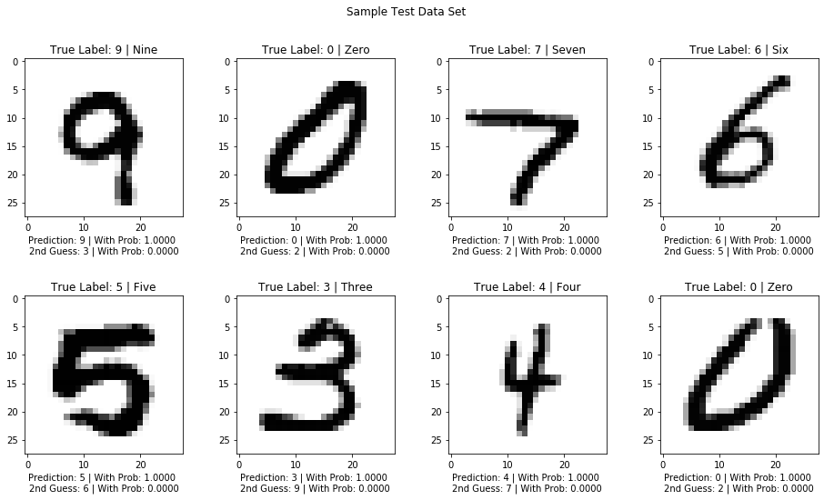

```python
visualize_prediction(test_x_orig, test_y_orig.T, prediction_test,dataset_type = "test")
```

#### Visualizing Mislabelled Images in all datasets

```
Total Mislabelled Images: 54
```

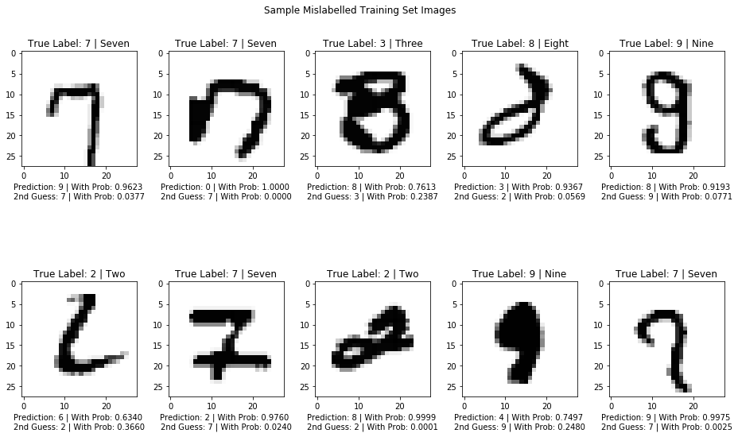

```python
visualize_mislabelled_images(train_x_split, train_y_split.T,prediction_train,dataset_type = "training")
```

```
Total Mislabelled Images: 142
```

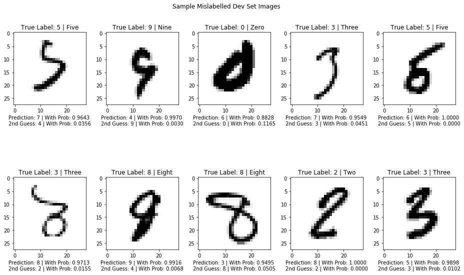

```python
visualize_mislabelled_images(dev_x_split, dev_y_split.T, prediction_dev,dataset_type = "dev")
```

```
Total Mislabelled Images: 141
```

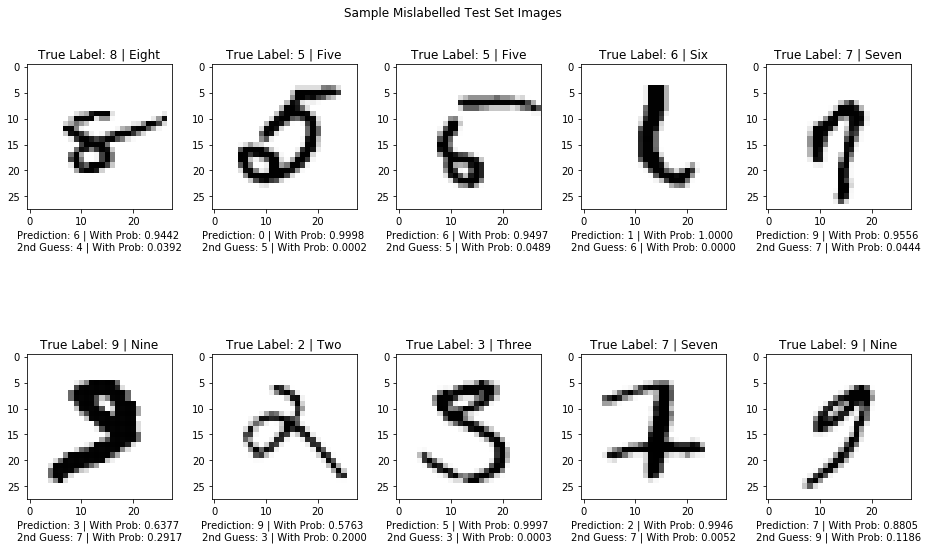

```python
visualize_mislabelled_images(test_x_orig, test_y_orig.T, prediction_test,dataset_type = "test")
```

### Predicting Real Time images

```python
from PIL import Image
```

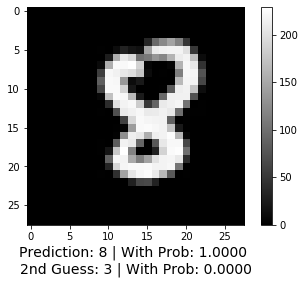

```python
image_name = "8_1.jpg"

fname = "Sample Images/" + image_name

image_data = np.asarray(Image.open(fname).convert('L').resize((28,28)))
if image_data[1,1] > 250: #if background is white, reversing the fore and background color to match training images
            image_data = 255 - image_data
def predict_real_time(image_data, second_guess = True):
    image_flattened = image_data.reshape(image_data.shape[0]*image_data.shape[1],-1)
    image_norm =(image_flattened/255.)

    prediction = predict(image_norm, params, second_guess = second_guess)

    return prediction

prediction = predict_real_time(image_data, second_guess = True)

first_lbl, first_prob = prediction["First Prediction"]
sec_lbl, sec_prob = prediction["Second Prediction"]

# plt.title("True Label: "+ str(label.squeeze()))
plt.xlabel("Prediction: %d | With Prob: %.4f \n2nd Guess: %d | With Prob: %.4f"%(first_lbl, first_prob, sec_lbl, sec_prob), fontsize = 14)
plt.imshow(image_data, interpolation ='nearest',cmap='gray')
plt.colorbar()
```

## Saving and Loading model

```python
# from datetime import date

# d = date.today()

path = "Saved Models/"
fname = "online_Augmented_model_200k_test_acc_"+str(acc)

print(fname)

model = {"Parameters": params,
         "Activations": ["relu","softmax"],
## Save the following info if needed
         "Hyper Parameters": hyperParams,
         "initialization":"he",
         "regularizer":"dropout",
         "optimizer":"adam"
        }
save_model(file_name = path+fname, model = model)
```

```
online_Augmented_model_200k_test_acc_0.9859
```

```python
# loading model
path = "Saved Models/"

model = load_model(file_name =path+ "online_Augmented_model_200k_test_acc_0.9859")

loaded_params = model["Parameters"]
```

```python
L = len(loaded_params) // 2
print("Total Layers %d: "%L)
for l in range(L):
    print(loaded_params["W" + str(l+1)].shape[0])
```

## To Do

- [ ] Optimize and refactor the code
- [ ] Prepare the doc String
- [x] add verbose: Integer. 0, 1, 2 or 3. Verbosity mode.
- [ ] Batch norm
- [ ] Maxout
- [ ] Drop Connect
- [x] Data Augmentation if possible

```python
!jupyter-nbconvert --to html 'Project Modules Evaluation with online data augmentation.ipynb' --output Experiments/experiment-8/tuned_data_aug_200k.html
```